# Web scraping Falcon 9 and Falcon Heavy Launches Records from Wikipedia

# TASK 3: Create a data frame by parsing the launch HTML tables

We will create an empty dictionary with keys from the extracted column names in the previous task. Later, this dictionary will be converted into a Pandas dataframe

```python
launch_dict= dict.fromkeys(column_names)

# Remove an irrelvant column
del launch_dict['Date and time ( )']

# Let's initial the launch_dict with each value to be an empty list
launch_dict['Flight No.'] = []
launch_dict['Launch site'] = []
launch_dict['Payload'] = []
launch_dict['Payload mass'] = []
launch_dict['Orbit'] = []
launch_dict['Customer'] = []
launch_dict['Launch outcome'] = []
# Added some new columns
launch_dict['Version Booster']=[]
launch_dict['Booster landing']=[]
launch_dict['Date']=[]
launch_dict['Time']=[]
```

Next, we just need to fill up the launch_dict with launch records extracted from table rows.

Usually, HTML tables in Wiki pages are likely to contain unexpected annotations and other types of noises, such as reference links B0004.1[8], missing values N/A [e], inconsistent formatting, etc.

To simplify the parsing process, we have provided an incomplete code snippet below to help you to fill up the launch_dict. Please complete the following code snippet with TODOs or you can choose to write your own logic to parse all launch tables:

```python
extracted_row = 0
#Extract each table
for table_number,table in enumerate(soup.find_all('table',"wikitable plainrowheaders collapsible")):
   # get table row
    for rows in table.find_all("tr"):
        #check to see if first table heading is as number corresponding to launch a number
        if rows.th:
            if rows.th.string:
                flight_number=rows.th.string.strip()
                flag=flight_number.isdigit()
        else:
            flag=False
        #get table element
        row=rows.find_all('td')
        #if it is number save cells in a dictonary
        if flag:
            extracted_row += 1
            # Flight Number value
            # TODO: Append the flight_number into launch_dict with key `Flight No.`
            launch_dict['Flight No.'].append(flight_number)
            #print(flight_number)
            datatimelist=date_time(row[0])

            # Date value
            # TODO: Append the date into launch_dict with key `Date`
            date = datatimelist[0].strip(',')
            launch_dict['Date'].append(date)
            #print(date)

            # Time value
             # TODO: Append the time into launch_dict with key `Time`
            time = datatimelist[1]
            launch_dict['Time'].append(time)
            #print(time)

            # Booster version
            # TODO: Append the bv into launch_dict with key `Version Booster`
            bv=booster_version(row[1])
            if not(bv):
                bv=row[1].a.string
            print(bv)
            launch_dict['Version Booster'].append(bv)

            # Launch Site
            # TODO: Append the bv into launch_dict with key `Launch Site`
            launch_site = row[2].a.string
            launch_dict['Launch site'].append(launch_site)
            #print(launch_site)

            # Payload
            # TODO: Append the payload into launch_dict with key `Payload`
            payload = row[3].a.string
            #print(payload)
            launch_dict['Payload'].append(payload)

            # Payload Mass
            # TODO: Append the payload_mass into launch_dict with key `Payload mass`
            payload_mass = get_mass(row[4])
            launch_dict['Payload mass'].append(payload_mass)
            #print(payload)

            # Orbit
            # TODO: Append the orbit into launch_dict with key `Orbit`
            orbit = row[5].a.string
            launch_dict['Orbit'].append(orbit)
            #print(orbit)

            # Customer
            # TODO: Append the customer into launch_dict with key `Customer`
            try:
                customer = row[6].a.string
            except:
                customer = 'Various'
            launch_dict['Customer'].append(customer)
            #print(customer)

            # Launch outcome
            # TODO: Append the launch_outcome into launch_dict with key `Launch outcome`
            launch_outcome = list(row[7].strings)[0]
            launch_dict['Launch outcome'].append(launch_outcome)
            #print(launch_outcome)

            # Booster landing
            # TODO: Append the launch_outcome into launch_dict with key `Booster landing`
            booster_landing = landing_status(row[8])
            launch_dict['Booster landing'].append(booster_landing)
            #print(booster_landing)
```

F9 v1.0B0003.1 F9 v1.0B0004.1 F9 v1.0B0005.1 F9 v1.0B0006.1 F9 v1.0B0007.1 F9 v1.1B1003 F9 v1.1 F9 v1.1 F9 v1.1 F9 v1.1 F9 v1.1 F9 v1.1 F9 v1.1 F9 v1.1 F9 v1.1 F9 v1.1 F9 v1.1 F9 v1.1 F9 v1.1 F9 FT F9 v1.1 F9 FT F9 FT F9 FT F9 FT F9 FT F9 FT F9 FT F9 FT F9 FT F9 FT F9 FT♺ F9 FT F9 FT F9 FT F9 FTB1029.2 F9 FT F9 FT F9 B4 F9 FT F9 B4 F9 B4 F9 FTB1031.2 F9 B4 F9 FTB1035.2 F9 FTB1036.2 F9 B4 F9 FTB1032.2 F9 FTB1038.2 F9 B4 F9 B4B1041.2 F9 B4B1039.2 F9 B4 F9 B5B1046.1 F9 B4B1043.2 F9 B4B1040.2 F9 B4B1045.2 F9 B5 F9 B5B1048 F9 B5B1046.2 F9 B5 F9 B5B1048.2 F9 B5B1047.2 F9 B5B1046.3 F9 B5 F9 B5 F9 B5B1049.2 F9 B5B1048.3 F9 B5[268] F9 B5 F9 B5B1049.3 F9 B5B1051.2 F9 B5B1056.2 F9 B5B1047.3 F9 B5 F9 B5 F9 B5B1056.3 F9 B5 F9 B5 F9 B5 F9 B5 F9 B5 F9 B5 F9 B5 F9 B5 F9 B5 F9 B5 F9 B5 F9 B5B1058.2 F9 B5 F9 B5B1049.6 F9 B5 F9 B5B1060.2 F9 B5B1058.3 F9 B5B1051.6 F9 B5 F9 B5 F9 B5 F9 B5 F9 B5 ♺ F9 B5 ♺ F9 B5 ♺ F9 B5 ♺ F9 B5 F9 B5B1051.8 F9 B5B1058.5 F9 B5 ♺ F9 B5 ♺ F9 B5 ♺ F9 B5 ♺ F9 B5 ♺ F9 B5B1060.6 F9 B5 ♺ F9 B5B1061.2 F9 B5B1060.7 F9 B5B1049.9 F9 B5B1051.10 F9 B5B1058.8 F9 B5B1063.2 F9 B5B1067.1 F9 B5

After you have fill in the parsed launch record values into launch_dict, you can create a dataframe from it.

```python
df=pd.DataFrame(launch_dict)
df.head()
```

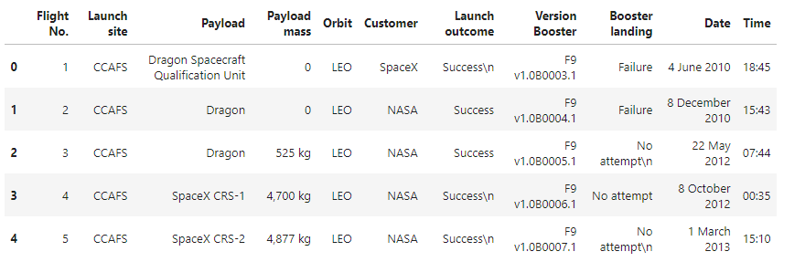

We can now export it to a CSV for the next section, but to make the answers consistent and in case you have difficulties finishing this lab.

Following labs will be using a provided dataset to make each lab independent.

```python
df.to_csv('spacex_web_scraped.csv', index=False)
```